# Análise do Dataset Iris

Bem-vindo ao meu notebook de análise do famoso dataset Iris! Neste projeto, exploraremos e analisaremos detalhadamente um conjunto de dados que é um dos pilares da ciência de dados e da análise estatística. O dataset Iris é frequentemente usado como um ponto de partida para iniciantes em análise de dados devido à sua simplicidade e riqueza em informações.

### Sobre o Dataset:

O dataset Iris contém informações sobre três espécies diferentes de flores de íris: setosa, versicolor e virginica. Cada espécie é representada por 50 amostras, totalizando 150 observações. Para cada amostra, temos quatro características medidas em centímetros: comprimento e largura das sépalas, e comprimento e largura das pétalas.

### Objetivo:

O objetivo deste notebook é realizar uma análise exploratória dos dados para entender as características das diferentes espécies de íris e identificar quais medidas são mais discriminantes para distinguir entre elas. Além disso, exploraremos visualizações, estatísticas descritivas e até mesmo criaremos modelos de aprendizado de máquina para classificação das espécies com base em suas características.

### Estrutura do Notebook:

- Começaremos importando as bibliotecas necessárias e carregando o dataset.
- Em seguida, realizaremos uma análise exploratória inicial, incluindo estatísticas descritivas e visualizações gráficas.
- Vamos investigar as relações entre as características e as espécies de íris.
- Implementaremos um algoritmo de aprendizado de máquina para classificação.
- Finalmente, resumiremos nossas descobertas e conclusões.

Este notebook é uma jornada de aprendizado e exploração de dados, e convido você a me acompanhar enquanto mergulhamos fundo na análise do dataset Iris. Vamos começar!

```python
from sklearn.datasets import load_iris
import pandas as pd
import seaborn as sns
import matplotlib.pyplot as plt
from sklearn.neighbors import KNeighborsClassifier
from sklearn.model_selection import train_test_split
from sklearn.metrics import classification_report
import warnings
warnings.filterwarnings('ignore')
```

Aqui criamos funções simples para nos auxiliar na análise:

```python
def matriz_confusao(y_true, y_pred):
    import seaborn as sns
    import matplotlib.pyplot as plt
    from sklearn.metrics import confusion_matrix
    conf_matrix = confusion_matrix(y_true, y_pred)
    plt.figure(figsize=(6, 4))
    sns.heatmap(conf_matrix, annot=True, cmap="Blues", cbar=False, fmt="d")
    plt.xlabel('Previsto')
    plt.ylabel('Real')
    plt.title('Matriz de Confusão')
    plt.show()
```

```python
def teste_shapiro(dataset, alpha):
    from scipy.stats import shapiro
    for coluna in dataset.columns:
        _, p = shapiro(dataset[coluna])
        if p > alpha:
            print(f"Os dados de {coluna} provavelmente seguem uma distribuição normal")
        else:
            print(f"Os dados de {coluna} provavelmente NÃO SEGUEM uma distribuição normal")
```

```python
def teste_normal(dados):
    from scipy.stats import probplot
    plt.figure(figsize=(6, 4))
    probplot(dados, plot=plt)
    plt.title("Gráfico de Probabilidade-Q-Q")
    plt.xlabel("Quantis teóricos")
    plt.ylabel("Quantis observados")
    plt.show()
```

```python
# Carregando o dataset
iris = load_iris()
```

```python
# Transformação do dataset dos atributos previsores em um DataFrame do Pandas para melhor visualização
X = pd.DataFrame(data=iris.data, columns=iris.feature_names)
```

```python
X.head()
```

|  | sepal length (cm) | sepal width (cm) | petal length (cm) | petal width (cm) |
| --- | --- | --- | --- | --- |
| 0 | 5.1 | 3.5 | 1.4 | 0.2 |
| 1 | 4.9 | 3.0 | 1.4 | 0.2 |
| 2 | 4.7 | 3.2 | 1.3 | 0.2 |
| 3 | 4.6 | 3.1 | 1.5 | 0.2 |
| 4 | 5.0 | 3.6 | 1.4 | 0.2 |

```python
X.tail()
```

|  | sepal length (cm) | sepal width (cm) | petal length (cm) | petal width (cm) |
| --- | --- | --- | --- | --- |
| 145 | 6.7 | 3.0 | 5.2 | 2.3 |
| 146 | 6.3 | 2.5 | 5.0 | 1.9 |
| 147 | 6.5 | 3.0 | 5.2 | 2.0 |
| 148 | 6.2 | 3.4 | 5.4 | 2.3 |
| 149 | 5.9 | 3.0 | 5.1 | 1.8 |

```python
# Nosso target, ou seja, os tipos das espécies de Iris
y = iris.target
```

```python
# informações sobre o dataset (indices, colunas, contagem de valores nulos(se houverem), e o tipo de dado que contem em
# cada coluna)
X.info()
```

```
<class 'pandas.core.frame.DataFrame'>
RangeIndex: 150 entries, 0 to 149
Data columns (total 4 columns):
 #   Column             Non-Null Count  Dtype
---  ------             --------------  -----
 0   sepal length (cm)  150 non-null    float64
 1   sepal width (cm)   150 non-null    float64
 2   petal length (cm)  150 non-null    float64
 3   petal width (cm)   150 non-null    float64
dtypes: float64(4)
memory usage: 4.8 KB
```

```python
# Informações estatísticas sobre o dataset
X.describe()
```

|  | sepal length (cm) | sepal width (cm) | petal length (cm) | petal width (cm) |
| --- | --- | --- | --- | --- |
| count | 150.000000 | 150.000000 | 150.000000 | 150.000000 |
| mean | 5.843333 | 3.057333 | 3.758000 | 1.199333 |
| std | 0.828066 | 0.435866 | 1.765298 | 0.762238 |
| min | 4.300000 | 2.000000 | 1.000000 | 0.100000 |
| 25% | 5.100000 | 2.800000 | 1.600000 | 0.300000 |
| 50% | 5.800000 | 3.000000 | 4.350000 | 1.300000 |
| 75% | 6.400000 | 3.300000 | 5.100000 | 1.800000 |
| max | 7.900000 | 4.400000 | 6.900000 | 2.500000 |

```python
# Verificando o nome das classes
iris.target_names
```

```
array(['setosa', 'versicolor', 'virginica'], dtype='<U10')
```

```python
# adicionando as classes ao DataFrame principal para melhor visualização
X['target'] = iris.target
```

```python
X.head()
```

|  | sepal length (cm) | sepal width (cm) | petal length (cm) | petal width (cm) | target |
| --- | --- | --- | --- | --- | --- |
| 0 | 5.1 | 3.5 | 1.4 | 0.2 | 0 |
| 1 | 4.9 | 3.0 | 1.4 | 0.2 | 0 |
| 2 | 4.7 | 3.2 | 1.3 | 0.2 | 0 |
| 3 | 4.6 | 3.1 | 1.5 | 0.2 | 0 |
| 4 | 5.0 | 3.6 | 1.4 | 0.2 | 0 |

```python
# mapeando as classes. Originalmente ela vem em formato numérico, alteramos conforme a documentação
map_target_names = {}
for i, class_name in enumerate(iris.target_names):
    map_target_names[i] = class_name

map_target_names
```

```
{0: 'setosa', 1: 'versicolor', 2: 'virginica'}
```

```python
X['target'] = X['target'].map(map_target_names)
```

```python
X.head()
```

|  | sepal length (cm) | sepal width (cm) | petal length (cm) | petal width (cm) | target |
| --- | --- | --- | --- | --- | --- |
| 0 | 5.1 | 3.5 | 1.4 | 0.2 | setosa |
| 1 | 4.9 | 3.0 | 1.4 | 0.2 | setosa |
| 2 | 4.7 | 3.2 | 1.3 | 0.2 | setosa |
| 3 | 4.6 | 3.1 | 1.5 | 0.2 | setosa |
| 4 | 5.0 | 3.6 | 1.4 | 0.2 | setosa |

```python
X.tail()
```

|  | sepal length (cm) | sepal width (cm) | petal length (cm) | petal width (cm) | target |
| --- | --- | --- | --- | --- | --- |
| 145 | 6.7 | 3.0 | 5.2 | 2.3 | virginica |
| 146 | 6.3 | 2.5 | 5.0 | 1.9 | virginica |
| 147 | 6.5 | 3.0 | 5.2 | 2.0 | virginica |
| 148 | 6.2 | 3.4 | 5.4 | 2.3 | virginica |
| 149 | 5.9 | 3.0 | 5.1 | 1.8 | virginica |

```python
#Separando as classes em uma varíavel
y = X['target'].copy()
```

```python
y
```

```
0         setosa
1         setosa
2         setosa
3         setosa
4         setosa
         ...
145    virginica
146    virginica
147    virginica
148    virginica
149    virginica
Name: target, Length: 150, dtype: object
```

```python
X.head()
```

|  | sepal length (cm) | sepal width (cm) | petal length (cm) | petal width (cm) | target |
| --- | --- | --- | --- | --- | --- |
| 0 | 5.1 | 3.5 | 1.4 | 0.2 | setosa |
| 1 | 4.9 | 3.0 | 1.4 | 0.2 | setosa |
| 2 | 4.7 | 3.2 | 1.3 | 0.2 | setosa |
| 3 | 4.6 | 3.1 | 1.5 | 0.2 | setosa |
| 4 | 5.0 | 3.6 | 1.4 | 0.2 | setosa |

```python
X.tail()
```

|  | sepal length (cm) | sepal width (cm) | petal length (cm) | petal width (cm) | target |
| --- | --- | --- | --- | --- | --- |
| 145 | 6.7 | 3.0 | 5.2 | 2.3 | virginica |
| 146 | 6.3 | 2.5 | 5.0 | 1.9 | virginica |
| 147 | 6.5 | 3.0 | 5.2 | 2.0 | virginica |
| 148 | 6.2 | 3.4 | 5.4 | 2.3 | virginica |
| 149 | 5.9 | 3.0 | 5.1 | 1.8 | virginica |

Podemos verificar que as classes estão igualmente distribuídas nesse dataset:

```python
X.target.value_counts()
```

```
setosa        50
versicolor    50
virginica     50
Name: target, dtype: int64
```

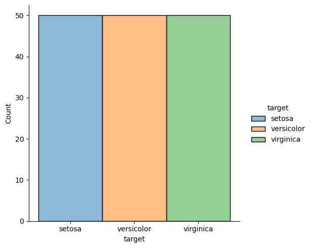

```python
sns.displot(data=X, x='target', hue='target');
```

Abaixo temos um gráfico de dispersão que podemos visualizar que os atributos das pétalas tendem a se distribuir de forma mais linear entre as diferentes classes de Iris(setosa, versicolor e virginica), enquanto o das sépalas estão mais sobrepostos.

Isso sugere que as características das pétalas são altamente informativas para diferenciar as espécies de Iris. No entanto, é importante lembrar que a escolha do modelo e outras considerações desempenham um papel importante na classificação.

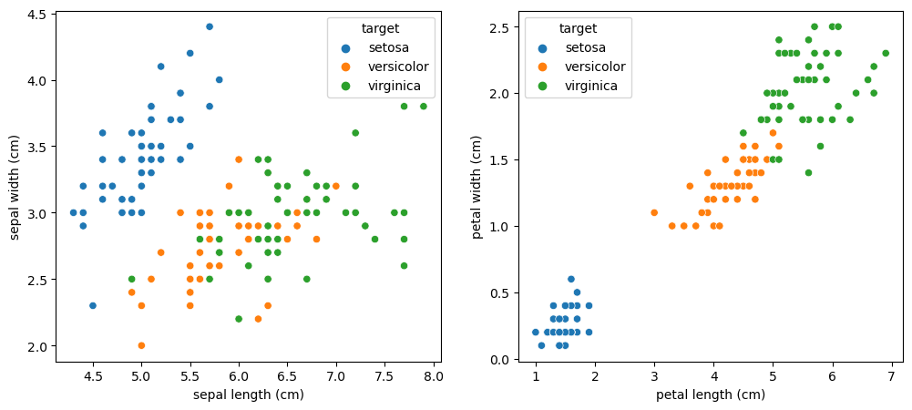

```python
fig, axs = plt.subplots(nrows=1, ncols=2, figsize=(12,5))
sns.scatterplot(data=X, x=X['sepal length (cm)'], y=X['sepal width (cm)'], hue='target', ax=axs[0])
sns.scatterplot(data=X, x=X['petal length (cm)'], y=X['petal width (cm)'], hue='target', ax=axs[1])
plt.show()
```

Aqui, agrupamos as médias dos atributos dos comprimentos e larguras das pétalas e sépalas por classe. Isso permitirá uma análise de como essas características médias variam entre as diferentes classes de flores (Setosa, Versicolor e Virginica) e complementará bem os gráficos de violino.

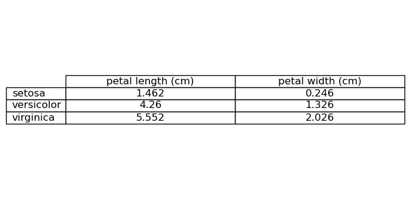

```python
medias_petalas = round(X.groupby('target')[['petal length (cm)', 'petal width (cm)']].mean(), 3)


fig, ax = plt.subplots(figsize=(6, 4))


ax.axis('off')


table = ax.table(cellText=medias_petalas.values,
                 colLabels=medias_petalas.columns,
                 rowLabels=medias_petalas.index,
                 cellLoc='center', loc='center')

table.auto_set_font_size(False)
table.set_fontsize(12)
table.scale(1.2, 1.2)


plt.show()
```

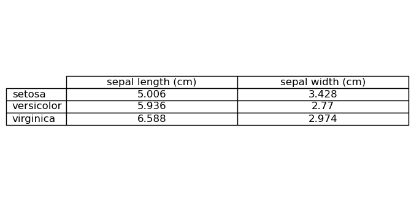

```python
medias_sepalas = round(X.groupby('target')[['sepal length (cm)', 'sepal width (cm)']].mean(), 3)

fig, ax = plt.subplots(figsize=(6, 4))


ax.axis('off')


table = ax.table(cellText=medias_sepalas.values,
                 colLabels=medias_sepalas.columns,
                 rowLabels=medias_sepalas.index,
                 cellLoc='center', loc='center')

table.auto_set_font_size(False)
table.set_fontsize(12)
table.scale(1.2, 1.2)


plt.show()
```

#### Vamos considerar os principais pontos de interpretação em um gráfico de violino:

- **Forma dos Violinos**: Os violinos são plotados para cada classe no eixo x (Setosa, Versicolor e Virginica). A forma de cada violino representa a distribuição da característica "Comprimento da Pétala" para essa classe. A largura do violino indica a densidade dos dados em diferentes partes da distribuição. Lugares mais largos indicam mais densidade.
- **Altura dos Violinos**: A altura do violino em diferentes partes da distribuição mostra a densidade dos dados nessa região. Lugares mais altos indicam que há mais pontos de dados nessa região.
- **Marcas Dentro dos Violinos**: As marcas (pontos ou pequenas linhas) dentro do violino mostram os valores reais dos dados (pontos de dados individuais). Eles podem ajudar a identificar a dispersão dos dados e possíveis outliers.
- **Gráfico de Caixa (Box Plot)**: Às vezes, um gráfico de caixa é desenhado dentro do violino. Ele fornece informações adicionais sobre a distribuição dos dados, incluindo a mediana (linha no centro da caixa), quartis (caixa) e possíveis outliers (pontos fora da caixa).

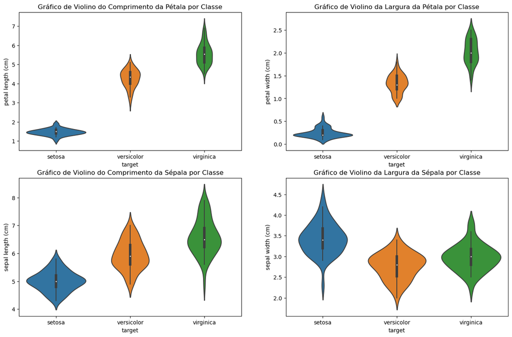

```python
fig, axs = plt.subplots(nrows=2, ncols=2, figsize=(16,10))
sns.violinplot(data=X, x='target', y=X['petal length (cm)'], ax=axs[0, 0])
sns.violinplot(data=X, x='target', y=X['petal width (cm)'], ax=axs[0, 1])
sns.violinplot(data=X, x='target', y=X['sepal length (cm)'], ax=axs[1, 0])
sns.violinplot(data=X, x='target', y=X['sepal width (cm)'], ax=axs[1, 1])
axs[0, 0].set_title('Gráfico de Violino do Comprimento da Pétala por Classe')
axs[0, 1].set_title('Gráfico de Violino da Largura da Pétala por Classe')
axs[1, 0].set_title('Gráfico de Violino do Comprimento da Sépala por Classe')
axs[1, 1].set_title('Gráfico de Violino da Largura da Sépala por Classe')

plt.show()
```

### Verificando a distribuição dos dados

Saber se os dados seguem uma distribuição normal é fundamental na estatística e ciência de dados. Isso é útil para aplicar corretamente métodos estatísticos, ajustar modelos, fazer previsões, controlar qualidade, realizar testes de hipóteses e generalizar resultados. Embora os dados raramente sejam perfeitamente normais, a verificação da normalidade ajuda a interpretar resultados com precisão e aplicar métodos adequados quando a normalidade não é atendida

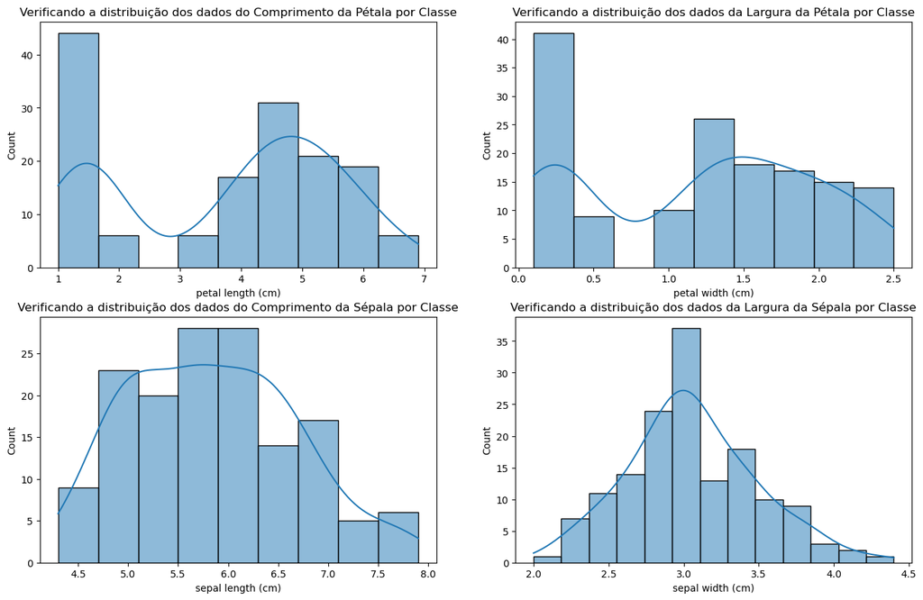

```python
fig, axs = plt.subplots(nrows=2, ncols=2, figsize=(16,10))
sns.histplot(X['petal length (cm)'], ax=axs[0, 0], kde=True)
sns.histplot(X['petal width (cm)'], ax=axs[0, 1], kde=True)
sns.histplot(X['sepal length (cm)'], ax=axs[1, 0], kde=True)
sns.histplot(X['sepal width (cm)'], ax=axs[1, 1], kde=True)
axs[0, 0].set_title('Verificando a distribuição dos dados do Comprimento da Pétala por Classe')
axs[0, 1].set_title('Verificando a distribuição dos dados da Largura da Pétala por Classe')
axs[1, 0].set_title('Verificando a distribuição dos dados do Comprimento da Sépala por Classe')
axs[1, 1].set_title('Verificando a distribuição dos dados da Largura da Sépala por Classe');
```

### Gráfico Q-Q (Quantile-Quantile): Uma Comparação Visual

O gráfico Q-Q é como uma comparação visual entre o que esperamos e o que realmente vemos em nossos dados:

No eixo horizontal, colocamos o que esperaríamos em um mundo perfeito. No eixo vertical, colocamos o que realmente temos em nossos dados. Se os pontos formarem uma linha reta, é um bom sinal; nossos dados se encaixam bem no que esperávamos. Se a linha se desviar, pode haver surpresas interessantes nos dados.

É uma maneira rápida de ver se nossos dados têm um comportamento desejado, como seguir uma curva específica, como uma distribuição normal. É útil para entender melhor os dados e tomar decisões sobre como usá-los.

```
                               Sepal Length (Cm)
```

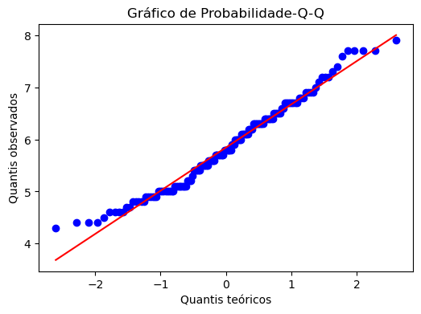

```
                                Sepal Width (Cm)
```

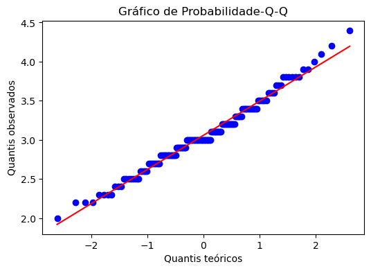

```
                               Petal Length (Cm)
```

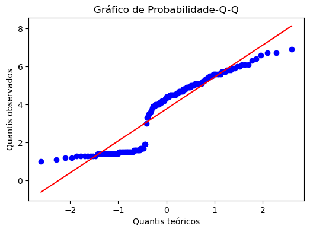

```
                                Petal Width (Cm)
```

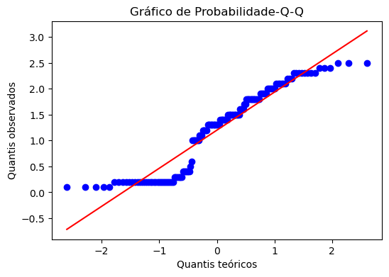

```python
for coluna in X.drop('target', axis=1):
    print(str(coluna.title().center(80, ' ')))
    teste_normal(X[coluna])
```

```python
# verificar distribuição dos dados com o teste de Shapiro-Wilk
teste_shapiro(X.drop(columns='target'), 0.01)
```

```
Os dados de sepal length (cm) provavelmente seguem uma distribuição normal
Os dados de sepal width (cm) provavelmente seguem uma distribuição normal
Os dados de petal length (cm) provavelmente NÃO SEGUEM uma distribuição normal
Os dados de petal width (cm) provavelmente NÃO SEGUEM uma distribuição normal
```

### Correlações

Nas análises do conjunto de dados Iris, foram identificadas correlações significativas entre várias características das flores. Observou-se uma forte correlação positiva entre o comprimento da sépala e o comprimento da pétala, bem como entre o comprimento da sépala e a largura da pétala, ou seja, quando o valor de um atributo aumenta, o outro atributo tende a aumentar também. Além disso, uma correlação negativa moderada foi encontrada entre a largura da sépala e o comprimento da pétala, quanto maior um atributo, o outro tende a diminuir. Destacaram-se também correlações notáveis entre o comprimento e a largura da pétala, ambas muito fortes e positivas. Essas correlações revelam insights importantes sobre as relações entre as características das flores e podem ser valiosas para análises futuras.

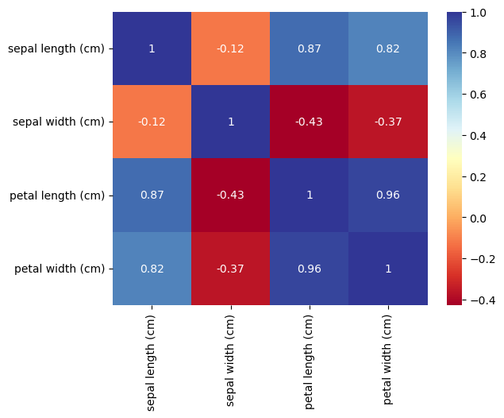

```python
sns.heatmap(X.corr(), annot=True, cmap='RdYlBu');
```

```python
def correlacoes(dataset):
    matriz_correlacao = dataset.corr()
    for indice, linha in matriz_correlacao.iterrows():
        for coluna, valor_correlacao in linha.iteritems():
            if (valor_correlacao >= 0.90 and valor_correlacao < 1) or (valor_correlacao <= -0.90 and valor_correlacao > -1):
                print(f"Correlação MUITO FORTE entre {indice} e {coluna}: {valor_correlacao}")
                print("\n")
            if (valor_correlacao >= 0.70 and valor_correlacao <= 0.89) or (valor_correlacao <= -0.70 and valor_correlacao >= -0.89):
                print(f"Correlação FORTE entre {indice} e {coluna}: {valor_correlacao}")
                print("\n")
            if (valor_correlacao >= 0.40 and valor_correlacao <= 0.69) or (valor_correlacao <= -0.40 and valor_correlacao >= -0.69):
                print(f"Correlação MODERADA entre {indice} e {coluna}: {valor_correlacao}")
                print("\n")
```

```python
correlacoes(X)
```

```
Correlação FORTE entre sepal length (cm) e petal length (cm): 0.8717537758865838


Correlação FORTE entre sepal length (cm) e petal width (cm): 0.8179411262715758


Correlação MODERADA entre sepal width (cm) e petal length (cm): -0.42844010433053864


Correlação FORTE entre petal length (cm) e sepal length (cm): 0.8717537758865838


Correlação MODERADA entre petal length (cm) e sepal width (cm): -0.42844010433053864


Correlação MUITO FORTE entre petal length (cm) e petal width (cm): 0.962865431402796


Correlação FORTE entre petal width (cm) e sepal length (cm): 0.8179411262715758


Correlação MUITO FORTE entre petal width (cm) e petal length (cm): 0.962865431402796
```

### Avaliação da Classificação de Espécies de Iris: A Importância dos Atributos

No meu projeto de classificação das espécies de Iris, comecei por separar os dados em um conjunto de treinamento e um conjunto de teste. Inicialmente, concentrei-me apenas nos atributos das pétalas das flores, usando o código:

```python
X_petalas = X[['petal length (cm)', 'petal width (cm)']].copy()
```

```python
X_treino, X_teste, y_treino, y_teste = train_test_split(X_petalas, y, test_size=0.2, stratify=y, random_state=2)
```

Em seguida, utilizei o algoritmo K-Nearest Neighbors (KNN) para treinar um modelo de classificação com base nos dados de treinamento e, posteriormente, o utilizei para fazer previsões sobre o conjunto de teste. O resultado foi surpreendente:

```python
clf = KNeighborsClassifier(n_neighbors=5)
clf.fit(X_treino, y_treino)
y_pred = clf.predict(X_teste)
print(classification_report(y_teste, y_pred))
```

```
              precision    recall  f1-score   support

      setosa       1.00      1.00      1.00        10
  versicolor       1.00      1.00      1.00        10
   virginica       1.00      1.00      1.00        10

    accuracy                           1.00        30
   macro avg       1.00      1.00      1.00        30
weighted avg       1.00      1.00      1.00        30
```

O modelo obteve uma precisão e recall de 100% para todas as classes, indicando que ele foi capaz de classificar perfeitamente as espécies de Iris com base apenas nos atributos das pétalas. Isso foi uma descoberta impressionante e mostrou a importância desses atributos na diferenciação das espécies.

Porém, é preciso ficar atento a possibilidade de ter ocorrido um overfitting, ou seja, o modelo se ajusta demais aos dados de treino e acaba "decorando" as informações.

A matriz de confusão é uma ferramenta para avaliar a precisão de modelos de classificação. No Conjunto de Dados Iris, que possui três classes de flores, ela nos ajuda a ver quão bem um modelo distingue entre essas classes. Ela contém valores como Verdadeiro Positivo (previsão correta), Falso Positivo e Falso Negativo (previu incorretamente). Com base nesses valores, podemos calcular métricas de desempenho e melhorar o modelo. Em resumo, é uma ferramenta essencial para avaliar e melhorar modelos de classificação.

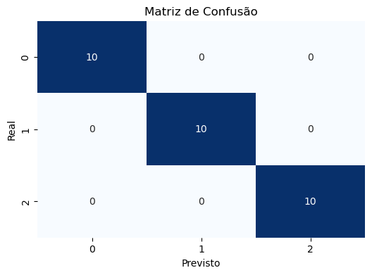

```python
matriz_confusao(y_teste, y_pred)
```

Em seguida, decidi expandir o escopo do meu modelo, considerando todos os atributos disponíveis, usando o código:

```python
X_treino, X_teste, y_treino, y_teste = train_test_split(X.drop('target', axis=1), y, test_size=0.2, stratify=y, random_state=2)
```

O resultado foi igualmente interessante:

```python
clf = KNeighborsClassifier(n_neighbors=5)
clf.fit(X_treino, y_treino)
y_pred = clf.predict(X_teste)
print(classification_report(y_teste, y_pred))
```

```
              precision    recall  f1-score   support

      setosa       1.00      1.00      1.00        10
  versicolor       1.00      0.90      0.95        10
   virginica       0.91      1.00      0.95        10

    accuracy                           0.97        30
   macro avg       0.97      0.97      0.97        30
weighted avg       0.97      0.97      0.97        30
```

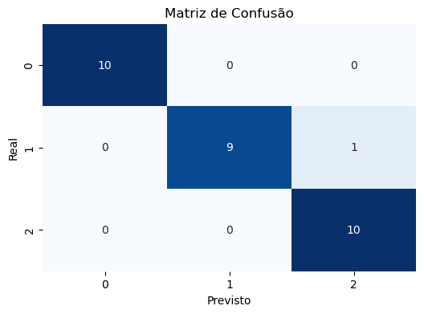

```python
matriz_confusao(y_teste, y_pred)
```

Nesse cenário, ao considerar todos os atributos disponíveis, o modelo ainda apresentou um desempenho muito bom, com uma precisão geral de 97%. No entanto, houve alguma diminuição na precisão (É a proporção de previsões positivas corretas em relação ao total de previsões positivas.) para a classe "virginica" e recall (É a proporção de previsões positivas corretas em relação ao total de exemplos positivos verdadeiros.) para a classe "versicolor". Isso destaca que, embora todos os atributos tenham contribuído para um modelo de alta precisão, os atributos das pétalas desempenharam um papel fundamental na classificação perfeita inicial.

Essa análise demonstra como a escolha dos atributos pode afetar significativamente o desempenho de um modelo de classificação e destaca a importância da exploração dos dados em projetos de aprendizado de máquina.

# Conclusão

Em resumo, a análise do dataset Iris não apenas nos forneceu informações valiosas sobre as espécies de íris, mas também serviu como uma excelente introdução à análise de dados e à construção de modelos de aprendizado de máquina. Essa jornada de aprendizado continua, e a aplicação de técnicas de análise de dados a conjuntos de dados do mundo real é fundamental para desenvolver habilidades sólidas em ciência de dados.

Este projeto é um exemplo do poder da análise de dados para extrair insights significativos a partir de informações aparentemente simples. À medida que continuamos nossa jornada em análise e ciência de dados, é essencial lembrar que há sempre mais a aprender e explorar.